# Clean 5 - relative importance

TG

2026-05-15

# In this script:

# In this script:

This script estimates the relative importance of temperature, protection, and invasive biomass for taxonomic diversity, functional diversity, and biomass responses. It first fits linear models for all diversity and biomass facets, including total native biomass and biomass split by commercial value. Relative importance is estimated using bootstrap-based `relaimpo` analyses and visualized as bar plots and ternary plots.

The script also fits temperature × protection interaction models and creates interaction plots for diversity and native biomass responses. These interaction plots are combined with the ternary plot into a multi-panel figure.

Finally, the script evaluates spatial autocorrelation using SAR error models. It selects a spatial neighborhood distance based on AIC, fits SAR models for all diversity and biomass responses, compares Moran’s I before and after SAR correction, extracts SAR-adjusted response values, and reruns relative importance analyses after removing the spatial component.

*Input data:*

- `diversity_table_natives.rdata` - rarefied TD and FD diversity estimates for native communities
- `medata_multistressor.rdata` - cleaned Mediterranean fish transect metadata for this project
- `site_biomass_commercial.rdata` - biomass of native species split by commercial value
- `final_commercial_list.rdata` - final species-level commercial value classification

*Output data:*

- Ternary plots showing the relative importance of temperature, protection, and NIS for diversity and biomass responses
- Temperature × protection interaction plots for diversity and native biomass responses
- Combined multi-panel figure with interaction plots and ternary plot
- `Table_relative_importance.csv` - table of relative importance values and model R²
- `Moran_I_comparison_LM_vs_SAR.csv` - Moran’s I comparison before and after SAR correction
- `coef_compare_LM_vs_SAR.csv` - comparison of LM and SAR coefficients, p-values, and significance changes
- Ternary plots of relative importance after removing the spatial component

### load packages

```r
library(tidyverse)
library(relaimpo)
library(patchwork)
library(ggiraphExtra)
library(ggeffects)
library(ggtern)
library(here)
library(spdep)
library(spatialreg)
```

```r
select<-dplyr::select

rela_plots<-"4_relative importance"
```

### load data

```r
load(here("2_data_for_analyses", "medata_multistressor.rdata"))
load(here("2_data_for_analyses", "site_biomass_commercial.rdata"))
load(here("2_data_for_analyses", "final_commercial_list.rdata"))
load(here("3_diversity tables", "diversity_table_natives.rdata"))
```

# Create lm

diversity models

```r
# diversity

TD_richness<-lm(TD_richness ~ tmean + protection + Invasive_biomass,data = diversity_table)

TD_shannon<-lm(TD_shannon ~ tmean + protection + Invasive_biomass,data = diversity_table)

TD_simpson<-lm(log(TD_simpson) ~ tmean + protection + Invasive_biomass,data = diversity_table)

FD_richness<-lm(FD_richness ~ tmean + protection + Invasive_biomass,data = diversity_table)

FD_shannon<-lm(FD_shannon ~ tmean + protection + Invasive_biomass,data = diversity_table)

FD_simpson<-lm(FD_simpson ~ tmean + protection + Invasive_biomass,data = diversity_table)
```

biomass model

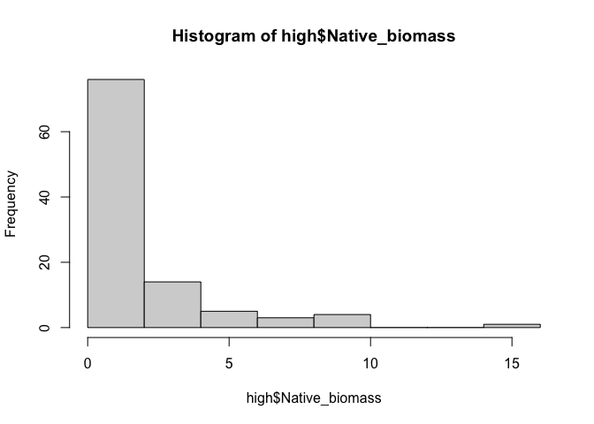

```r
# split the commercial data by value

high <- biomass_commer %>% filter(Commercial_value=="High")
medium <- biomass_commer %>% filter(Commercial_value=="Medium")
none <- biomass_commer %>% filter(Commercial_value=="None")

# check if normal distributions

hist(high$Native_biomass)
```

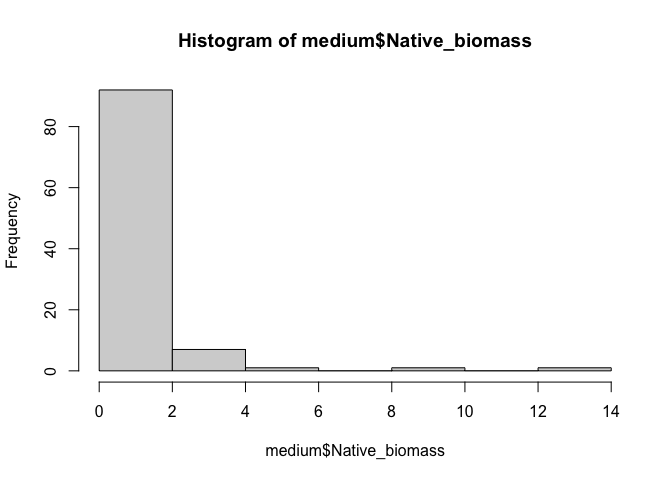

```r
hist(medium$Native_biomass)
```

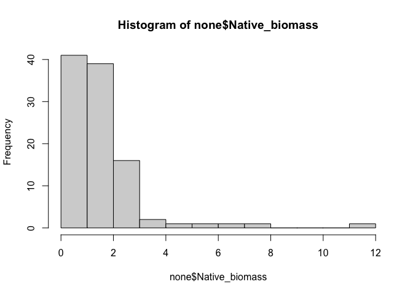

```r
hist(none$Native_biomass)
```

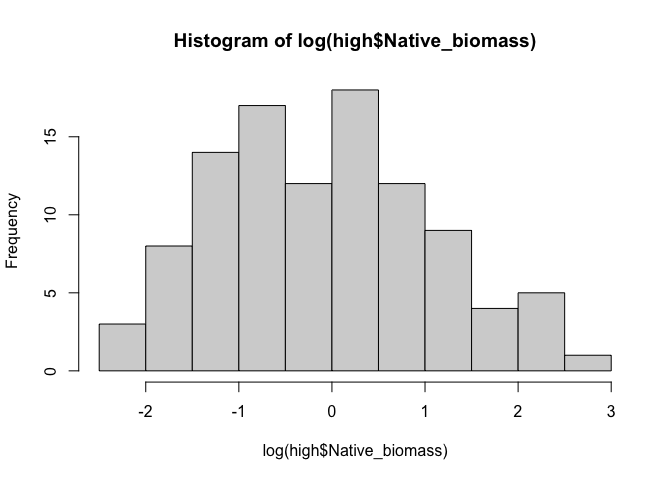

```r
# nope - convert to log...

hist(log(high$Native_biomass))
```

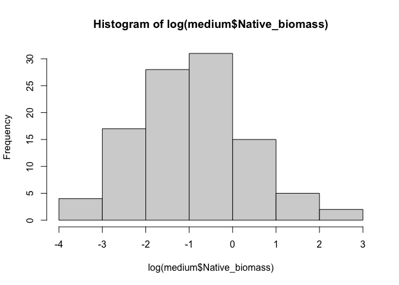

```r
hist(log(medium$Native_biomass))
```

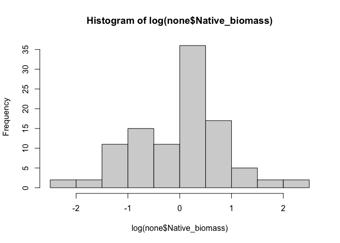

```r
hist(log(none$Native_biomass))
```

lm models

```r
# biomass (total)

Biomass<-lm(log(Native_biomass) ~ tmean + protection + Invasive_biomass,data = diversity_table)

# set of linear models

bio_high<-lm(log(Native_biomass)~ tmean + protection + Invasive_biomass,data = high)

bio_medium<-lm(log(Native_biomass)~ tmean + protection + Invasive_biomass,data = medium)

bio_none<-lm(log(Native_biomass)~ tmean + protection + Invasive_biomass,data = none)
```

# Relative importance

a function that calculate, plot and save the relative importance for each y

`boot.relimp()` - conducts the bootstrap

`booteval.relimp()` - gets the confidence intervals

it also provide the relative in data fit to plot ternary plots

```r
plot_my_rela <- function(model, response_name, plot_title = response_name,
                         save_plot = FALSE, upperl = 1, rela_plots = NULL) {

  # bootstrap relative importance

  rl_boot <- boot.relimp(model, b = 1000, rela = TRUE)
  ci <- booteval.relimp(rl_boot)

  print(ci)

  # data for bar plot

  data <- as.data.frame(ci@mark)
  colnames(data) <- c("var_explained", "sign", "lower_ci", "upper_ci")

  data <- data %>%
    mutate(
      var_explained = as.numeric(var_explained),
      lower_ci = as.numeric(lower_ci),
      upper_ci = as.numeric(upper_ci),
      variable = rownames(data),
      variable = case_when(
        grepl("tmean", variable) ~ "Temperature",
        grepl("protection", variable) ~ "Protection",
        grepl("Invasive_biomass", variable) ~ "NIS"
      ),
      variable = ordered(variable, c("Temperature", "Protection", "NIS"))
    )

  total_var <- ci@R2

  # data for ternary plot
  rela_out <- data %>%
    select(variable, var_explained) %>%
    pivot_wider(names_from = variable, values_from = var_explained) %>%
    mutate(response = response_name) %>%
    select(response, Temperature, Protection, NIS)

  # bar plot
  plot <- ggplot(data = data, aes(x = variable, y = var_explained, fill = variable)) +
    geom_bar(stat = "identity") +
    theme_classic() +
    ylab("Variance explained") +
    labs(
      title = plot_title,
      subtitle = bquote(R^2 == .(round((total_var * 100), 2)) * "%")
    ) +
    ylim(0, upperl) +
    theme(
      legend.position = "none",
      axis.title.x = element_blank(),
      axis.text = element_text(size = 20),
      axis.title = element_text(size = 24),
      plot.title = element_text(size = 26, hjust = 0.5),
      plot.subtitle = element_text(size = 18, hjust = 0.5)
    ) +
    scale_fill_manual(values = c("#364D8B", "#03718A", "#30A3D1"))


  if (save_plot) {
    plot_name <- paste0("Relative importance - ", plot_title, ".pdf")
    ggsave(
      plot = plot,
      filename = plot_name,
      width = 10,
      height = 8,
      dpi = 300,
      path = rela_plots
    )
  }

  return(list(
    plot = plot,
    rela = rela_out,
    ci_data = data,
    R2 = total_var
  ))
}
```

run over diversity and biomass indeces

```r
td_richness_rela <- plot_my_rela(model = TD_richness, response_name = "TD richness", upperl = 0.7, save_plot = FALSE)
```

```
## Response variable: TD_richness
## Total response variance: 18.54688
## Analysis based on 103 observations
##
## 3 Regressors:
## tmean protection Invasive_biomass
## Proportion of variance explained by model: 20.71%
## Metrics are normalized to sum to 100% (rela=TRUE).
##
## Relative importance metrics:
##
##                        lmg
## tmean            0.4346788
## protection       0.3773729
## Invasive_biomass 0.1879484
##
## Average coefficients for different model sizes:
##
##                         1X        2Xs        3Xs
## tmean            -1.015199 -0.8556402 -0.6339981
## protection        3.069142  2.4845268  2.2250472
## Invasive_biomass -1.284809 -0.7619921 -0.5357014
##
##
##  Confidence interval information ( 1000 bootstrap replicates, bty= perc ):
## Relative Contributions with confidence intervals:
##
##                                     Lower  Upper
##                      percentage 0.95 0.95   0.95
## tmean.lmg            0.4347     ABC  0.2155 0.6797
## protection.lmg       0.3774     ABC  0.0769 0.6024
## Invasive_biomass.lmg 0.1879     ABC  0.0953 0.4332
##
## Letters indicate the ranks covered by bootstrap CIs.
## (Rank bootstrap confidence intervals always obtained by percentile method)
## CAUTION: Bootstrap confidence intervals can be somewhat liberal.
##
##
##  Differences between Relative Contributions:
##
##                                                 Lower   Upper
##                                 difference 0.95 0.95    0.95
## tmean-protection.lmg             0.0573         -0.3565  0.5832
## tmean-Invasive_biomass.lmg       0.2467         -0.1414  0.5163
## protection-Invasive_biomass.lmg  0.1894         -0.2736  0.4719
##
## * indicates that CI for difference does not include 0.
## CAUTION: Bootstrap confidence intervals can be somewhat liberal.
```

```r
td_shannon_rela <- plot_my_rela(model = TD_shannon, response_name = "TD shannon", upperl = 1, save_plot = FALSE)
```

```
## Response variable: TD_shannon
## Total response variance: 6.772214
## Analysis based on 103 observations
##
## 3 Regressors:
## tmean protection Invasive_biomass
## Proportion of variance explained by model: 14.17%
## Metrics are normalized to sum to 100% (rela=TRUE).
##
## Relative importance metrics:
##
##                         lmg
## tmean            0.14905388
## protection       0.81988545
## Invasive_biomass 0.03106067
##
## Average coefficients for different model sizes:
##
##                          1X        2Xs        3Xs
## tmean            -0.3193241 -0.2398643 -0.1155186
## protection        2.0313570  1.9300956  1.8808749
## Invasive_biomass -0.2857285 -0.0672080 -0.0794792
##
##
##  Confidence interval information ( 1000 bootstrap replicates, bty= perc ):
## Relative Contributions with confidence intervals:
##
##                                     Lower  Upper
##                      percentage 0.95 0.95   0.95
## tmean.lmg            0.1491     _BC  0.0408 0.4518
## protection.lmg       0.8199     A__  0.4596 0.9434
## Invasive_biomass.lmg 0.0311     _BC  0.0095 0.2031
##
## Letters indicate the ranks covered by bootstrap CIs.
## (Rank bootstrap confidence intervals always obtained by percentile method)
## CAUTION: Bootstrap confidence intervals can be somewhat liberal.
##
##
##  Differences between Relative Contributions:
##
##                                                 Lower   Upper
##                                 difference 0.95 0.95    0.95
## tmean-protection.lmg            -0.6708     *   -0.8982 -0.0124
## tmean-Invasive_biomass.lmg       0.1180         -0.0756  0.3945
## protection-Invasive_biomass.lmg  0.7888     *    0.3465  0.9254
##
## * indicates that CI for difference does not include 0.
## CAUTION: Bootstrap confidence intervals can be somewhat liberal.
```

```r
td_simpson_rela <- plot_my_rela(model = TD_simpson, response_name = "TD simpson", upperl = 1, save_plot = FALSE)
```

```
## Response variable: log(TD_simpson)
## Total response variance: 0.2379258
## Analysis based on 103 observations
##
## 3 Regressors:
## tmean protection Invasive_biomass
## Proportion of variance explained by model: 9.17%
## Metrics are normalized to sum to 100% (rela=TRUE).
##
## Relative importance metrics:
##
##                         lmg
## tmean            0.03258296
## protection       0.93473700
## Invasive_biomass 0.03268004
##
## Average coefficients for different model sizes:
##
##                           1X         2Xs         3Xs
## tmean            -0.01726077 -0.01039213 0.003150535
## protection        0.30785730  0.31886527 0.317163131
## Invasive_biomass  0.01879790  0.04361942 0.030593020
##
##
##  Confidence interval information ( 1000 bootstrap replicates, bty= perc ):
## Relative Contributions with confidence intervals:
##
##                                     Lower  Upper
##                      percentage 0.95 0.95   0.95
## tmean.lmg            0.0326     _BC  0.0167 0.4232
## protection.lmg       0.9347     AB_  0.3365 0.9703
## Invasive_biomass.lmg 0.0327     _BC  0.0058 0.4072
##
## Letters indicate the ranks covered by bootstrap CIs.
## (Rank bootstrap confidence intervals always obtained by percentile method)
## CAUTION: Bootstrap confidence intervals can be somewhat liberal.
##
##
##  Differences between Relative Contributions:
##
##                                                 Lower   Upper
##                                 difference 0.95 0.95    0.95
## tmean-protection.lmg            -0.9022         -0.9471  0.0632
## tmean-Invasive_biomass.lmg      -0.0001         -0.2934  0.2935
## protection-Invasive_biomass.lmg  0.9021         -0.0342  0.9629
##
## * indicates that CI for difference does not include 0.
## CAUTION: Bootstrap confidence intervals can be somewhat liberal.
```

```r
fd_richness_rela <- plot_my_rela(model = FD_richness, response_name = "FD richness", upperl = 0.7, save_plot = FALSE)
```

```
## Response variable: FD_richness
## Total response variance: 0.4728165
## Analysis based on 103 observations
##
## 3 Regressors:
## tmean protection Invasive_biomass
## Proportion of variance explained by model: 21.49%
## Metrics are normalized to sum to 100% (rela=TRUE).
##
## Relative importance metrics:
##
##                        lmg
## tmean            0.3362199
## protection       0.3633797
## Invasive_biomass 0.3004005
##
## Average coefficients for different model sizes:
##
##                          1X        2Xs         3Xs
## tmean            -0.1543735 -0.1175180 -0.06886199
## protection        0.4833525  0.3909585  0.37344334
## Invasive_biomass -0.2453855 -0.1775916 -0.15779107
##
##
##  Confidence interval information ( 1000 bootstrap replicates, bty= perc ):
## Relative Contributions with confidence intervals:
##
##                                     Lower  Upper
##                      percentage 0.95 0.95   0.95
## tmean.lmg            0.3362     ABC  0.1481 0.5397
## protection.lmg       0.3634     ABC  0.0898 0.6141
## Invasive_biomass.lmg 0.3004     ABC  0.1490 0.5917
##
## Letters indicate the ranks covered by bootstrap CIs.
## (Rank bootstrap confidence intervals always obtained by percentile method)
## CAUTION: Bootstrap confidence intervals can be somewhat liberal.
##
##
##  Differences between Relative Contributions:
##
##                                                 Lower   Upper
##                                 difference 0.95 0.95    0.95
## tmean-protection.lmg            -0.0272         -0.4444  0.3970
## tmean-Invasive_biomass.lmg       0.0358         -0.3583  0.2985
## protection-Invasive_biomass.lmg  0.0630         -0.4568  0.4292
##
## * indicates that CI for difference does not include 0.
## CAUTION: Bootstrap confidence intervals can be somewhat liberal.
```

```r
fd_shannon_rela <- plot_my_rela(model = FD_shannon, response_name = "FD shannon", upperl = 1, save_plot = FALSE)
```

```
## Response variable: FD_shannon
## Total response variance: 0.1543112
## Analysis based on 103 observations
##
## 3 Regressors:
## tmean protection Invasive_biomass
## Proportion of variance explained by model: 16.66%
## Metrics are normalized to sum to 100% (rela=TRUE).
##
## Relative importance metrics:
##
##                        lmg
## tmean            0.3092338
## protection       0.5277424
## Invasive_biomass 0.1630238
##
## Average coefficients for different model sizes:
##
##                           1X         2Xs         3Xs
## tmean            -0.07350551 -0.05785511 -0.03586088
## protection        0.28350905  0.24497801  0.23231814
## Invasive_biomass -0.09653877 -0.05807274 -0.04913357
##
##
##  Confidence interval information ( 1000 bootstrap replicates, bty= perc ):
## Relative Contributions with confidence intervals:
##
##                                     Lower  Upper
##                      percentage 0.95 0.95   0.95
## tmean.lmg            0.3092     ABC  0.1030 0.6242
## protection.lmg       0.5277     ABC  0.1257 0.7537
## Invasive_biomass.lmg 0.1630     ABC  0.0700 0.4790
##
## Letters indicate the ranks covered by bootstrap CIs.
## (Rank bootstrap confidence intervals always obtained by percentile method)
## CAUTION: Bootstrap confidence intervals can be somewhat liberal.
##
##
##  Differences between Relative Contributions:
##
##                                                 Lower   Upper
##                                 difference 0.95 0.95    0.95
## tmean-protection.lmg            -0.2185         -0.6218  0.4683
## tmean-Invasive_biomass.lmg       0.1462         -0.2567  0.4460
## protection-Invasive_biomass.lmg  0.3647         -0.2533  0.6566
##
## * indicates that CI for difference does not include 0.
## CAUTION: Bootstrap confidence intervals can be somewhat liberal.
```

```r
fd_simpson_rela <- plot_my_rela(model = FD_simpson, response_name = "FD simpson", upperl = 1, save_plot = FALSE)
```

```
## Response variable: FD_simpson
## Total response variance: 0.09640959
## Analysis based on 103 observations
##
## 3 Regressors:
## tmean protection Invasive_biomass
## Proportion of variance explained by model: 14.92%
## Metrics are normalized to sum to 100% (rela=TRUE).
##
## Relative importance metrics:
##
##                        lmg
## tmean            0.3087894
## protection       0.5876092
## Invasive_biomass 0.1036014
##
## Average coefficients for different model sizes:
##
##                           1X         2Xs         3Xs
## tmean            -0.05375216 -0.04390526 -0.02939427
## protection        0.22198250  0.19573151  0.18338596
## Invasive_biomass -0.06041808 -0.02947651 -0.02189403
##
##
##  Confidence interval information ( 1000 bootstrap replicates, bty= perc ):
## Relative Contributions with confidence intervals:
##
##                                     Lower  Upper
##                      percentage 0.95 0.95   0.95
## tmean.lmg            0.3088     ABC  0.0867 0.6320
## protection.lmg       0.5876     ABC  0.1473 0.8340
## Invasive_biomass.lmg 0.1036     ABC  0.0381 0.4380
##
## Letters indicate the ranks covered by bootstrap CIs.
## (Rank bootstrap confidence intervals always obtained by percentile method)
## CAUTION: Bootstrap confidence intervals can be somewhat liberal.
##
##
##  Differences between Relative Contributions:
##
##                                                 Lower   Upper
##                                 difference 0.95 0.95    0.95
## tmean-protection.lmg            -0.2788         -0.7329  0.4429
## tmean-Invasive_biomass.lmg       0.2052         -0.2504  0.5139
## protection-Invasive_biomass.lmg  0.4840         -0.1805  0.7770
##
## * indicates that CI for difference does not include 0.
## CAUTION: Bootstrap confidence intervals can be somewhat liberal.
```

```r
biomass_all_rela <- plot_my_rela(model = Biomass, response_name = "Native biomass", upperl = 1, save_plot = FALSE)
```

```
## Response variable: log(Native_biomass)
## Total response variance: 0.8019454
## Analysis based on 103 observations
##
## 3 Regressors:
## tmean protection Invasive_biomass
## Proportion of variance explained by model: 28.05%
## Metrics are normalized to sum to 100% (rela=TRUE).
##
## Relative importance metrics:
##
##                         lmg
## tmean            0.73265230
## protection       0.17803318
## Invasive_biomass 0.08931452
##
## Average coefficients for different model sizes:
##
##                           1X        2Xs        3Xs
## tmean            -0.25296758 -0.2806252 -0.3077452
## protection        0.55684529  0.4193951  0.2394195
## Invasive_biomass -0.07951908  0.1040322  0.2443573
##
##
##  Confidence interval information ( 1000 bootstrap replicates, bty= perc ):
## Relative Contributions with confidence intervals:
##
##                                     Lower  Upper
##                      percentage 0.95 0.95   0.95
## tmean.lmg            0.7327     A__  0.5103 0.8597
## protection.lmg       0.1780     _BC  0.0296 0.4140
## Invasive_biomass.lmg 0.0893     _BC  0.0573 0.1869
##
## Letters indicate the ranks covered by bootstrap CIs.
## (Rank bootstrap confidence intervals always obtained by percentile method)
## CAUTION: Bootstrap confidence intervals can be somewhat liberal.
##
##
##  Differences between Relative Contributions:
##
##                                                 Lower   Upper
##                                 difference 0.95 0.95    0.95
## tmean-protection.lmg             0.5546     *    0.1055  0.8198
## tmean-Invasive_biomass.lmg       0.6433     *    0.4124  0.7691
## protection-Invasive_biomass.lmg  0.0887         -0.1225  0.3418
##
## * indicates that CI for difference does not include 0.
## CAUTION: Bootstrap confidence intervals can be somewhat liberal.
```

```r
biomass_high_rela <- plot_my_rela(model = bio_high, response_name = "High commercial value", upperl = 1, save_plot = FALSE)
```

```
## Response variable: log(Native_biomass)
## Total response variance: 1.352575
## Analysis based on 103 observations
##
## 3 Regressors:
## tmean protection Invasive_biomass
## Proportion of variance explained by model: 30.26%
## Metrics are normalized to sum to 100% (rela=TRUE).
##
## Relative importance metrics:
##
##                        lmg
## tmean            0.4124867
## protection       0.4840833
## Invasive_biomass 0.1034300
##
## Average coefficients for different model sizes:
##
##                           1X        2Xs        3Xs
## tmean            -0.25933307 -0.2838561 -0.2971767
## protection        1.08941412  0.9928051  0.8056743
## Invasive_biomass  0.02056252  0.2458022  0.3604768
##
##
##  Confidence interval information ( 1000 bootstrap replicates, bty= perc ):
## Relative Contributions with confidence intervals:
##
##                                     Lower  Upper
##                      percentage 0.95 0.95   0.95
## tmean.lmg            0.4125     AB_  0.1702 0.6489
## protection.lmg       0.4841     ABC  0.1836 0.7502
## Invasive_biomass.lmg 0.1034     _BC  0.0450 0.2530
##
## Letters indicate the ranks covered by bootstrap CIs.
## (Rank bootstrap confidence intervals always obtained by percentile method)
## CAUTION: Bootstrap confidence intervals can be somewhat liberal.
##
##
##  Differences between Relative Contributions:
##
##                                                 Lower   Upper
##                                 difference 0.95 0.95    0.95
## tmean-protection.lmg            -0.0716         -0.5715  0.4498
## tmean-Invasive_biomass.lmg       0.3091     *    0.0412  0.5297
## protection-Invasive_biomass.lmg  0.3807         -0.0125  0.6787
##
## * indicates that CI for difference does not include 0.
## CAUTION: Bootstrap confidence intervals can be somewhat liberal.
```

```r
biomass_medium_rela <- plot_my_rela(model = bio_medium, response_name = "Medium commercial value", upperl = 1, save_plot = FALSE)
```

```
## Response variable: log(Native_biomass)
## Total response variance: 1.501939
## Analysis based on 102 observations
##
## 3 Regressors:
## tmean protection Invasive_biomass
## Proportion of variance explained by model: 15.96%
## Metrics are normalized to sum to 100% (rela=TRUE).
##
## Relative importance metrics:
##
##                        lmg
## tmean            0.1013718
## protection       0.2411657
## Invasive_biomass 0.6574625
##
## Average coefficients for different model sizes:
##
##                           1X         2Xs        3Xs
## tmean            -0.01257238 -0.07761342 -0.1435044
## protection        0.52456779  0.58892809  0.4580636
## Invasive_biomass  0.38374400  0.49874317  0.5516827
##
##
##  Confidence interval information ( 1000 bootstrap replicates, bty= perc ):
## Relative Contributions with confidence intervals:
##
##                                     Lower  Upper
##                      percentage 0.95 0.95   0.95
## tmean.lmg            0.1014     _BC  0.0495 0.3379
## protection.lmg       0.2412     ABC  0.0116 0.5420
## Invasive_biomass.lmg 0.6575     AB_  0.3209 0.8830
##
## Letters indicate the ranks covered by bootstrap CIs.
## (Rank bootstrap confidence intervals always obtained by percentile method)
## CAUTION: Bootstrap confidence intervals can be somewhat liberal.
##
##
##  Differences between Relative Contributions:
##
##                                                 Lower   Upper
##                                 difference 0.95 0.95    0.95
## tmean-protection.lmg            -0.1398         -0.4803  0.2270
## tmean-Invasive_biomass.lmg      -0.5561     *   -0.7925 -0.0685
## protection-Invasive_biomass.lmg -0.4163         -0.8585  0.2006
##
## * indicates that CI for difference does not include 0.
## CAUTION: Bootstrap confidence intervals can be somewhat liberal.
```

```r
biomass_none_rela <- plot_my_rela(model = bio_none, response_name = "No commercial value", upperl = 1, save_plot = FALSE)
```

```
## Response variable: log(Native_biomass)
## Total response variance: 0.7835033
## Analysis based on 103 observations
##
## 3 Regressors:
## tmean protection Invasive_biomass
## Proportion of variance explained by model: 19.52%
## Metrics are normalized to sum to 100% (rela=TRUE).
##
## Relative importance metrics:
##
##                         lmg
## tmean            0.78172129
## protection       0.05206094
## Invasive_biomass 0.16621777
##
## Average coefficients for different model sizes:
##
##                            1X        2Xs          3Xs
## tmean            -0.224139564 -0.2339325 -0.250234062
## protection        0.009223621 -0.1611390 -0.285846071
## Invasive_biomass -0.243934375 -0.1348280 -0.003301946
##
##
##  Confidence interval information ( 1000 bootstrap replicates, bty= perc ):
## Relative Contributions with confidence intervals:
##
##                                     Lower  Upper
##                      percentage 0.95 0.95   0.95
## tmean.lmg            0.7817     A__  0.4753 0.8679
## protection.lmg       0.0521     _BC  0.0134 0.3582
## Invasive_biomass.lmg 0.1662     _BC  0.0729 0.3687
##
## Letters indicate the ranks covered by bootstrap CIs.
## (Rank bootstrap confidence intervals always obtained by percentile method)
## CAUTION: Bootstrap confidence intervals can be somewhat liberal.
##
##
##  Differences between Relative Contributions:
##
##                                                 Lower   Upper
##                                 difference 0.95 0.95    0.95
## tmean-protection.lmg             0.7297     *    0.1508  0.8372
## tmean-Invasive_biomass.lmg       0.6155     *    0.1745  0.7791
## protection-Invasive_biomass.lmg -0.1142         -0.3213  0.2338
##
## * indicates that CI for difference does not include 0.
## CAUTION: Bootstrap confidence intervals can be somewhat liberal.
```

## ternary plots

all the data wrangling needed

```r
rela_diversity_df <- bind_rows(
  td_richness_rela$rela,
  td_shannon_rela$rela,
  td_simpson_rela$rela,
  fd_richness_rela$rela,
  fd_shannon_rela$rela,
  fd_simpson_rela$rela,
  biomass_all_rela$rela) %>%
                        mutate(facet = case_when(
                                      grepl("^TD", response) ~ "Taxonomic",
                                      grepl("^FD", response) ~ "Functional",
                                      response == "Native biomass" ~ "Biomass"),
                               index = case_when(
                                      grepl("richness", response, ignore.case = TRUE) ~ "Richness",
                                      grepl("shannon", response, ignore.case = TRUE) ~ "Shannon",
                                      grepl("simpson", response, ignore.case = TRUE) ~ "Simpson",
                                      response == "Native biomass" ~ "Biomass"))

div_colors <- c(
  "TD richness" = "#08306B",
  "TD shannon" = "#4292C6",
  "TD simpson" = "#9ECAE1",
  "FD richness" = "#67000D",
  "FD shannon" = "#EF3B2C",
  "FD simpson" = "#FCAE91",
  "Native biomass" ="#41AE76"
)
```

Ternary plot

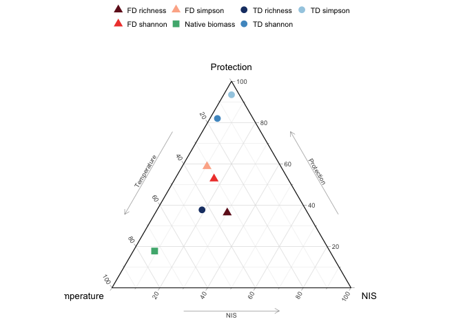

```r
div_ternary <- ggtern(rela_diversity_df,
                             aes(x = Temperature, y = Protection, z = NIS)) +
  geom_point(aes(color = response, shape = response), size = 3.2, alpha = 0.95) +
  labs(x = "Temperature", y = "Protection", z = "NIS", color = NULL, shape = NULL) +
  scale_color_manual(values = div_colors) +
  scale_shape_manual(values = c("TD richness" = 16,
                                "TD shannon" = 16,
                                "TD simpson" = 16,
                                "FD richness" = 17,
                                "FD shannon" = 17,
                                "FD simpson" = 17,
                                "Native biomass" = 15)) +
  theme_bw(base_size = 8) +
  theme_showarrows() +
  theme(legend.position = "top",
        legend.text = element_text(size = 8),
        legend.key.size = unit(0.4, "cm"),
        tern.axis.title.T = element_text(size = 10),
        tern.axis.title.L = element_text(size = 10),
        tern.axis.title.R = element_text(size = 10),
        tern.axis.text.T = element_text(size = 7),
        tern.axis.text.L = element_text(size = 7),
        tern.axis.text.R = element_text(size = 7),
        tern.axis.arrow.text.T = element_text(size = 7),
        tern.axis.arrow.text.L = element_text(size = 7),
        tern.axis.arrow.text.R = element_text(size = 7),
        tern.panel.grid.major = element_line(color = "grey88", linewidth = 0.25),
        plot.margin = margin(1, 1, 1, 1))

div_ternary
```

```r
# ggsave(here("4_relative importance", "Ternary_relative_importance_diversity.pdf"),
#        plot = div_ternary, width = 8.5, height = 8.5, units = "cm")
```

### relative importance plots for biomass models

```r
rela_biomass_df <- bind_rows(
  biomass_high_rela$rela,
  biomass_medium_rela$rela,
  biomass_none_rela$rela)


rela_biomass_df <- rela_biomass_df %>%
  mutate(response_short = recode(response,
                                 "High commercial value" = "High",
                                 "Medium commercial value" = "Medium",
                                 "No commercial value" = "No value"))

bio_colors <- c("High" = "#00798C",
                "Medium" = "#70A288",
                "No value" = "#D9ED92")
```

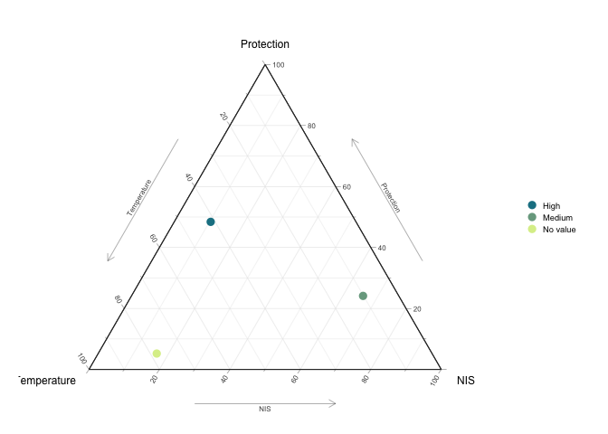

```r
bio_ternary <- ggtern(rela_biomass_df, aes(x = Temperature, y = Protection, z = NIS)) +
  geom_point(aes(color = response_short, size = response_short), shape = 16, alpha = 0.95) +
  labs(x = "Temperature", y = "Protection", z = "NIS", color = NULL, size = NULL) +
  scale_color_manual(values = bio_colors) +
  scale_size_manual(values = c("Total" = 4.2, "High" = 3.0, "Medium" = 3.0, "No value" = 3.0)) +
  theme_bw(base_size = 8) +
  theme_showarrows() +
  theme(legend.position = "right",
        legend.text = element_text(size = 7),
        legend.key.size = unit(0.35, "cm"),
        tern.axis.title.T = element_text(size = 9),
        tern.axis.title.L = element_text(size = 9),
        tern.axis.title.R = element_text(size = 9),
        tern.axis.text.T = element_text(size = 6),
        tern.axis.text.L = element_text(size = 6),
        tern.axis.text.R = element_text(size = 6),
        tern.axis.arrow.text.T = element_text(size = 6),
        tern.axis.arrow.text.L = element_text(size = 6),
        tern.axis.arrow.text.R = element_text(size = 6),
        tern.panel.grid.major = element_line(color = "grey90", linewidth = 0.2),
        plot.margin = margin(3, 10, 3, 3))

bio_ternary
```

```r
# ggsave(
#   filename = here("4_relative importance", "Ternary_relative_importance_biomass.pdf"),
#   plot = bio_ternary,
#   width = 8.5,
#   height = 8.5,
#   units = "cm"
# )
```

# Interaction model

create interaction model and prepare for ploting for each Y variable

temp * protection

### TD Richness

```r
i_TD_richness<-lm(TD_richness ~ tmean *  protection ,data = diversity_table)

summary(i_TD_richness)
```

```
##
## Call:
## lm(formula = TD_richness ~ tmean * protection, data = diversity_table)
##
## Residuals:
##     Min      1Q  Median      3Q     Max
## -9.3086 -2.3190 -0.5707  1.9487 10.4066
##
## Coefficients:
##                           Estimate Std. Error t value Pr(>|t|)
## (Intercept)                27.5178     6.2154   4.427 2.46e-05 ***
## tmean                      -0.9282     0.3072  -3.021   0.0032 **
## protectionProtected        -4.2628    10.1848  -0.419   0.6765
## tmean:protectionProtected   0.3284     0.5229   0.628   0.5314
## ---
## Signif. codes:  0 '***' 0.001 '**' 0.01 '*' 0.05 '.' 0.1 ' ' 1
##
## Residual standard error: 3.906 on 99 degrees of freedom
## Multiple R-squared:  0.2015, Adjusted R-squared:  0.1773
## F-statistic: 8.327 on 3 and 99 DF,  p-value: 5.42e-05
```

```r
p_i_TD_richness <- ggpredict(i_TD_richness,
                       terms = c('tmean[16:24 by=0.5]',
                                 "protection"))

colnames(p_i_TD_richness)<-c("Temperature","predicted","std.error","conf.low","conf.high","Protection" )
```

### TD shannon

```r
i_TD_shannon<-lm(TD_shannon ~ tmean *  protection ,data = diversity_table)

summary(i_TD_shannon)
```

```
##
## Call:
## lm(formula = TD_shannon ~ tmean * protection, data = diversity_table)
##
## Residuals:
##     Min      1Q  Median      3Q     Max
## -4.4714 -1.3062 -0.3474  0.7026  8.1690
##
## Coefficients:
##                           Estimate Std. Error t value Pr(>|t|)
## (Intercept)                6.12596    3.89353   1.573    0.119
## tmean                     -0.11155    0.19244  -0.580    0.563
## protectionProtected        3.59526    6.38006   0.564    0.574
## tmean:protectionProtected -0.08923    0.32758  -0.272    0.786
##
## Residual standard error: 2.447 on 99 degrees of freedom
## Multiple R-squared:  0.1419, Adjusted R-squared:  0.1159
## F-statistic: 5.455 on 3 and 99 DF,  p-value: 0.001637
```

```r
p_i_TD_shannon <- ggpredict(i_TD_shannon,
                       terms = c('tmean[16:24 by=0.5]',
                                 "protection"))

colnames(p_i_TD_shannon)<-c("Temperature","predicted","std.error","conf.low","conf.high","Protection" )
```

### TD simpson

```r
i_TD_simpson<-lm(log(TD_simpson) ~ tmean *  protection ,data = diversity_table)

summary(i_TD_simpson)
```

```
##
## Call:
## lm(formula = log(TD_simpson) ~ tmean * protection, data = diversity_table)
##
## Residuals:
##      Min       1Q   Median       3Q      Max
## -1.10454 -0.28833 -0.02125  0.19448  1.26086
##
## Coefficients:
##                           Estimate Std. Error t value Pr(>|t|)
## (Intercept)                0.54530    0.75161   0.726    0.470
## tmean                      0.01767    0.03715   0.476    0.635
## protectionProtected        0.55930    1.23162   0.454    0.651
## tmean:protectionProtected -0.01214    0.06324  -0.192    0.848
##
## Residual standard error: 0.4724 on 99 degrees of freedom
## Multiple R-squared:  0.08977,    Adjusted R-squared:  0.06219
## F-statistic: 3.255 on 3 and 99 DF,  p-value: 0.02489
```

```r
p_i_TD_simpson <- ggpredict(i_TD_simpson,
                       terms = c('tmean[16:24 by=0.5]',
                                 "protection"))
```

[output not shown]

```r
colnames(p_i_TD_simpson)<-c("Temperature","predicted","std.error","conf.low","conf.high","Protection" )
```

### FD richness

```r
i_FD_richness<-lm(FD_richness ~ tmean *  protection ,data = diversity_table)

summary(i_FD_richness)
```

```
##
## Call:
## lm(formula = FD_richness ~ tmean * protection, data = diversity_table)
##
## Residuals:
##     Min      1Q  Median      3Q     Max
## -1.4049 -0.3994 -0.1185  0.3203  1.6333
##
## Coefficients:
##                             Estimate Std. Error t value Pr(>|t|)
## (Intercept)                4.723e+00  1.003e+00   4.711 8.06e-06 ***
## tmean                     -1.221e-01  4.955e-02  -2.464   0.0155 *
## protectionProtected        3.408e-01  1.643e+00   0.207   0.8361
## tmean:protectionProtected -5.772e-05  8.435e-02  -0.001   0.9995
## ---
## Signif. codes:  0 '***' 0.001 '**' 0.01 '*' 0.05 '.' 0.1 ' ' 1
##
## Residual standard error: 0.6301 on 99 degrees of freedom
## Multiple R-squared:  0.185,  Adjusted R-squared:  0.1603
## F-statistic:  7.49 on 3 and 99 DF,  p-value: 0.0001435
```

```r
p_i_FD_richness <- ggpredict(i_FD_richness,
                       terms = c('tmean[16:24 by=0.5]',
                                 "protection"))

colnames(p_i_FD_richness)<-c("Temperature","predicted","std.error","conf.low","conf.high","Protection" )
```

### FD shannon

```r
i_FD_shannon<-lm(FD_shannon ~ tmean *  protection ,data = diversity_table)

summary(i_FD_shannon)
```

```
##
## Call:
## lm(formula = FD_shannon ~ tmean * protection, data = diversity_table)
##
## Residuals:
##      Min       1Q   Median       3Q      Max
## -0.74020 -0.21789 -0.03823  0.14300  1.21241
##
## Coefficients:
##                           Estimate Std. Error t value Pr(>|t|)
## (Intercept)                2.53258    0.58193   4.352 3.29e-05 ***
## tmean                     -0.04657    0.02876  -1.619    0.109
## protectionProtected        0.55211    0.95357   0.579    0.564
## tmean:protectionProtected -0.01702    0.04896  -0.348    0.729
## ---
## Signif. codes:  0 '***' 0.001 '**' 0.01 '*' 0.05 '.' 0.1 ' ' 1
##
## Residual standard error: 0.3657 on 99 degrees of freedom
## Multiple R-squared:  0.1587, Adjusted R-squared:  0.1332
## F-statistic: 6.225 on 3 and 99 DF,  p-value: 0.0006451
```

```r
p_i_FD_shannon <- ggpredict(i_FD_shannon,
                       terms = c('tmean[16:24 by=0.5]',
                                 "protection"))

colnames(p_i_FD_shannon)<-c("Temperature","predicted","std.error","conf.low","conf.high","Protection" )
```

### FD simpson

```r
i_FD_simpson<-lm(FD_simpson ~ tmean *  protection ,data = diversity_table)

summary(i_FD_simpson)
```

```
##
## Call:
## lm(formula = FD_simpson ~ tmean * protection, data = diversity_table)
##
## Residuals:
##      Min       1Q   Median       3Q      Max
## -0.56793 -0.18797 -0.04106  0.13750  0.94659
##
## Coefficients:
##                           Estimate Std. Error t value Pr(>|t|)
## (Intercept)                2.07859    0.46301   4.489 1.93e-05 ***
## tmean                     -0.03173    0.02288  -1.387    0.169
## protectionProtected        0.46286    0.75870   0.610    0.543
## tmean:protectionProtected -0.01464    0.03895  -0.376    0.708
## ---
## Signif. codes:  0 '***' 0.001 '**' 0.01 '*' 0.05 '.' 0.1 ' ' 1
##
## Residual standard error: 0.291 on 99 degrees of freedom
## Multiple R-squared:  0.1476, Adjusted R-squared:  0.1217
## F-statistic: 5.713 on 3 and 99 DF,  p-value: 0.001197
```

```r
p_i_FD_simpson <- ggpredict(i_FD_simpson,
                       terms = c('tmean[16:24 by=0.5]',
                                 "protection"))

colnames(p_i_FD_simpson)<-c("Temperature","predicted","std.error","conf.low","conf.high","Protection" )
```

```r
i_biomass<-lm(Native_biomass ~ tmean *  protection ,data = diversity_table)

summary(i_biomass)
```

```
##
## Call:
## lm(formula = Native_biomass ~ tmean * protection, data = diversity_table)
##
## Residuals:
##     Min      1Q  Median      3Q     Max
## -5.4612 -1.8253 -1.1447  0.3037 19.7265
##
## Coefficients:
##                           Estimate Std. Error t value Pr(>|t|)
## (Intercept)                13.7220     6.3921   2.147   0.0343 *
## tmean                      -0.5274     0.3159  -1.669   0.0982 .
## protectionProtected        10.2667    10.4743   0.980   0.3294
## tmean:protectionProtected  -0.4312     0.5378  -0.802   0.4246
## ---
## Signif. codes:  0 '***' 0.001 '**' 0.01 '*' 0.05 '.' 0.1 ' ' 1
##
## Residual standard error: 4.017 on 99 degrees of freedom
## Multiple R-squared:  0.152,  Adjusted R-squared:  0.1263
## F-statistic: 5.913 on 3 and 99 DF,  p-value: 0.0009391
```

```r
p_i_biomass <- ggpredict(i_biomass,
                       terms = c('tmean[16:24 by=0.5]',
                                 "protection"))

colnames(p_i_biomass)<-c("Temperature","predicted","std.error","conf.low","conf.high","Protection" )
```

### interaction plot function & theme

```r
interaction_theme <- theme_classic(base_size = 8) +
  theme(axis.text = element_text(size = 7),
        axis.title = element_text(size = 9),
        legend.position = c(0.68, 0.88),
        legend.justification = c(0, 1),
        legend.background = element_rect(fill = alpha("white", 0.75), color = NA),
        legend.text = element_text(size = 8),
        legend.title = element_blank(),
        legend.key.size = unit(0.35, "cm"),
        plot.margin = margin(3, 3, 3, 3))

make_interaction_plot <- function(pred_data, raw_y, ylab_text, col_hex) {
  ggplot(data = pred_data) +
    geom_ribbon(aes(x = Temperature, ymin = conf.low, ymax = conf.high, fill = Protection), alpha = 0.2) +
    geom_line(aes(x = Temperature, y = predicted, color = Protection), linewidth = 0.7) +
    geom_point(data = diversity_table, aes(x = tmean, y = {{ raw_y }}, color = protection), alpha = 0.25, size = 0.8) +
    xlab("Temperature (°C)") +
    ylab(ylab_text) +
    scale_color_manual(values = c("grey60", col_hex)) +
    scale_fill_manual(values = c("grey60", col_hex)) +
    guides(fill = "none") +
    interaction_theme
}
```

plot interaction plots

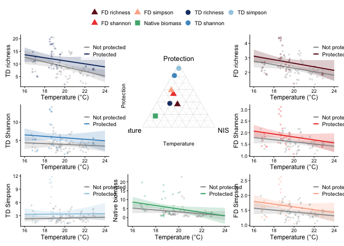

```r
p_td_rich <- make_interaction_plot(p_i_TD_richness, TD_richness, "TD richness", "#08306B")
p_td_shan <- make_interaction_plot(p_i_TD_shannon, TD_shannon, "TD Shannon", "#4292C6")
p_td_simp <- make_interaction_plot(p_i_TD_simpson, TD_simpson, "TD Simpson", "#9ECAE1")

p_fd_rich <- make_interaction_plot(p_i_FD_richness, FD_richness, "FD richness", "#67000D")
p_fd_shan <- make_interaction_plot(p_i_FD_shannon, FD_shannon, "FD Shannon", "#EF3B2C")
p_fd_simp <- make_interaction_plot(p_i_FD_simpson, FD_simpson, "FD Simpson", "#FCAE91")

p_biomass <- make_interaction_plot(p_i_biomass, Native_biomass, "Native biomass", "#41AE76")

# combined layout


layout_design <- "
ABC
DBE
FGH
"

combined_diversity_figure <- wrap_plots(
  A = p_td_rich,
  B = div_ternary,
  C = p_fd_rich,
  D = p_td_shan,
  E = p_fd_shan,
  F = p_td_simp,
  G = p_biomass,
  H = p_fd_simp,
  design = layout_design) +
  plot_layout(widths = c(1, 1.15, 1),
              heights = c(1, 1, 1))

combined_diversity_figure
```

```r
# ggsave(filename = here("4_relative importance",
#                        "Combined_interactions_ternary_diversity.pdf"),
#        plot = combined_diversity_figure,
#        width = 24,
#        height = 18,
#        units = "cm")
```

### create the diversity multuple plot - old style

[figure not shown]

```r
p_a <- td_richness_rela[["plot"]]
p_c <- td_shannon_rela[["plot"]]
p_e <- td_simpson_rela[["plot"]]

p_b <- fd_richness_rela[["plot"]]
p_d <- fd_shannon_rela[["plot"]]
p_f <- fd_simpson_rela[["plot"]]

                       # 3 rows, 2 columns
combined_plot <- (p_a | p_b) /
                 (p_c | p_d) /
                 (p_e | p_f)
# View it
combined_plot
```

```r
# ggsave("4_relative importance/All_relative_importance_panels.pdf", plot = combined_plot,width = 14, height = 12, dpi = 300)
# ggsave("4_relative importance/All_relative_importance_panels.png", plot = combined_plot,width = 14, height = 12, dpi = 300)


rm(p_a,p_b,p_c,p_d,p_e,p_f)
```

save table of all relative info

```r
rela_info<-rela_diversity_df %>% select(response,Temperature,Protection,NIS)
rela_bio<- rela_biomass_df %>% select(response,Temperature,Protection,NIS)

rela_info<-bind_rows(rela_info,rela_bio)

r2_info <- tibble(
  response = c("TD richness", "TD shannon", "TD simpson",
               "FD richness", "FD shannon", "FD simpson",
               "Native biomass", "High commercial value",
               "Medium commercial value", "No commercial value"),
  R2 = c(td_richness_rela$R2,
         td_shannon_rela$R2,
         td_simpson_rela$R2,
         fd_richness_rela$R2,
         fd_shannon_rela$R2,
         fd_simpson_rela$R2,
         biomass_all_rela$R2,
         biomass_high_rela$R2,
         biomass_medium_rela$R2,
         biomass_none_rela$R2))

rela_info <- rela_info %>%left_join(r2_info, by = "response")%>%
  mutate(across(c(Temperature, Protection, NIS, R2), ~round(.x * 100, 1)))

write_csv(rela_info,
          here("4_relative importance",
               "Table_relative_importance.csv"))
```

# SAR models

Step 1 — coordinates

```r
coords<- medata %>%
         select(site_id,lat,lon) %>%
         distinct() %>%
         filter(site_id %in% diversity_table$Assemblage) %>%
         group_by(site_id) %>%
         summarise(lat = mean(lat),lon = mean(lon))

colnames(coords)<-c("Assemblage","lat","lon")


diversity_table<-left_join(diversity_table,coords)
diversity_table<-diversity_table %>% relocate(c(lat,lon),.after = tmean)

rm(coords)

coords <- cbind(diversity_table$lon, diversity_table$lat)
```

Step 2 - Distances set

```r
dists_km <- c(2, 10, 25, 50, 100, 250, 500, 1000, 2000)
```

Step 3 - fit one SAR model per distance

ILL do it once for the richness model

```r
sar_results <- vector("list", length(dists_km))

for (i in seq_along(dists_km)) {

  d <- dists_km[i]

  # neighbors within 0 to d km

  nb <- dnearneigh(coords, d1 = 0, d2 = d, longlat = TRUE)

  # how many observations have no neighbors?
  n_isolates <- sum(card(nb) == 0)

  # if there are isolates, we can still create the weights object
  lw <- nb2listw(nb, style = "W", zero.policy = TRUE)

  # try fitting the SAR error model
  fit <- try(
    errorsarlm(
      TD_richness ~ tmean + protection + Invasive_biomass,
      data = diversity_table,
      listw = lw,
      zero.policy = TRUE,
      na.action = na.omit
    ),
    silent = TRUE
  )

  sar_results[[i]] <- list(
    distance_km = d,
    nb = nb,
    lw = lw,
    n_isolates = n_isolates,
    fit = fit,
    aic = if (inherits(fit, "try-error")) NA else AIC(fit)
  )
}
```

Step 4 — AIC table

```r
aic_table <- data.frame(
  distance_km = sapply(sar_results, `[[`, "distance_km"),
  isolates    = sapply(sar_results, `[[`, "n_isolates"),
  AIC         = sapply(sar_results, `[[`, "aic")
)

aic_table[order(aic_table$AIC), ]
```

```
##   distance_km isolates      AIC
## 6         250        0 530.1307
## 5         100        0 538.2795
## 4          50        8 543.7559
## 3          25       13 544.2875
## 2          10       23 552.6106
## 7         500        0 575.8137
## 9        2000        0 577.3569
## 8        1000        0 579.5078
## 1           2       83 580.1218
```

clean env and run it for all models

```r
rm(fit,lw,nb,sar_results,best_nb,best_lw,best_sar,best_i,nb,aic_table,coords,n_isolates,i,d,dists_km)
```

function guide:

• `dnearneigh` → defines who is connected to whom • `nb2listw` → defines how strongly they are connected • `errorsarlm` → fits model accounting for spatial autocorrelation

```r
coords <- cbind(diversity_table$lon, diversity_table$lat)

radius <- 250  # define neighborhood radius (250 km)

# create neighbor structure: which sites are within 250 km of each other

neighborhood <- dnearneigh(coords, 0, radius, longlat = TRUE)
# convert neighbors into spatial weights (row-standardized, W style)

spatial_weights <- nb2listw(neighborhood, style = "W", zero.policy = TRUE)
```

run the model + moran i test for each one of the variables + save results

diversity SAR models

```r
sar_td_richness <- errorsarlm(
  TD_richness ~ tmean + protection + Invasive_biomass,  # predictors
  data = diversity_table,
  listw = spatial_weights,        # spatial structure
  zero.policy = TRUE     # allow sites with no neighbors
)

sar_td_shannon <- errorsarlm(
  TD_shannon ~ tmean + protection + Invasive_biomass,  # predictors
  data = diversity_table,
  listw = spatial_weights,        # spatial structure
  zero.policy = TRUE     # allow sites with no neighbors
)

sar_td_simpson <- errorsarlm(
  log(TD_simpson) ~ tmean + protection + Invasive_biomass,  # predictors
  data = diversity_table,
  listw = spatial_weights,        # spatial structure
  zero.policy = TRUE     # allow sites with no neighbors
)


sar_fd_richness <- errorsarlm(
  FD_richness ~ tmean + protection + Invasive_biomass,  # predictors
  data = diversity_table,
  listw = spatial_weights,        # spatial structure
  zero.policy = TRUE     # allow sites with no neighbors
)


sar_fd_shannon <- errorsarlm(
  FD_shannon ~ tmean + protection + Invasive_biomass,  # predictors
  data = diversity_table,
  listw = spatial_weights,        # spatial structure
  zero.policy = TRUE     # allow sites with no neighbors
)


sar_fd_simpson <- errorsarlm(
  FD_simpson ~ tmean + protection + Invasive_biomass,  # predictors
  data = diversity_table,
  listw = spatial_weights,        # spatial structure
  zero.policy = TRUE     # allow sites with no neighbors
)
```

biomass sar models

```r
# reorder high and none to match diversity_table

high <- high %>% mutate(Assemblage = factor(Assemblage, levels = diversity_table$Assemblage)) %>% arrange(Assemblage) %>% mutate(Assemblage = as.character(Assemblage))

none <- none %>% mutate(Assemblage = factor(Assemblage, levels = diversity_table$Assemblage)) %>% arrange(Assemblage) %>% mutate(Assemblage = as.character(Assemblage))

# reorder medium as much as possible

medium <- medium %>% mutate(Assemblage = factor(Assemblage, levels = diversity_table$Assemblage)) %>% arrange(Assemblage) %>% mutate(Assemblage = as.character(Assemblage))

# separate weights only for medium

coords_for_m<-diversity_table %>% select(Assemblage,lat,lon)

medium<-left_join(medium,coords_for_m)
# Get the coords for medium

coords_medium <- cbind(medium$lon, medium$lat)
nb_medium <- dnearneigh(coords_medium, 0, 250, longlat = TRUE)
spatial_weights_medium <- nb2listw(nb_medium, style = "W", zero.policy = TRUE)

# SAR biomass models

sar_biomass <- errorsarlm(log(Native_biomass) ~ tmean + protection + Invasive_biomass,
                          data = diversity_table, listw = spatial_weights, zero.policy = TRUE)

sar_bio_high <- errorsarlm(log(Native_biomass) ~ tmean + protection + Invasive_biomass,
                           data = high, listw = spatial_weights, zero.policy = TRUE)

sar_bio_medium <- errorsarlm(log(Native_biomass) ~ tmean + protection + Invasive_biomass,
                             data = medium, listw = spatial_weights_medium, zero.policy = TRUE)

sar_bio_none <- errorsarlm(log(Native_biomass) ~ tmean + protection + Invasive_biomass,
                           data = none, listw = spatial_weights, zero.policy = TRUE)
```

save moran.I tests for sar and regular models

```r
# LM models

lm_models <- list(
  TD_richness = TD_richness,
  TD_shannon  = TD_shannon,
  TD_simpson  = TD_simpson,
  FD_richness = FD_richness,
  FD_shannon  = FD_shannon,
  FD_simpson  = FD_simpson,
  Biomass     = Biomass,
  High        = bio_high,
  Medium      = bio_medium,
  None        = bio_none)

# SAR models

sar_models <- list(
  TD_richness = sar_td_richness,
  TD_shannon  = sar_td_shannon,
  TD_simpson  = sar_td_simpson,
  FD_richness = sar_fd_richness,
  FD_shannon  = sar_fd_shannon,
  FD_simpson  = sar_fd_simpson,
  Biomass     = sar_biomass,
  High        = sar_bio_high,
  Medium      = sar_bio_medium,
  None        = sar_bio_none)

# biomass medium had different weights because 1 transect was missing

weights_list <- list(
  TD_richness = spatial_weights,
  TD_shannon  = spatial_weights,
  TD_simpson  = spatial_weights,
  FD_richness = spatial_weights,
  FD_shannon  = spatial_weights,
  FD_simpson  = spatial_weights,
  Biomass     = spatial_weights,
  High        = spatial_weights,
  Medium      = spatial_weights_medium,
  None        = spatial_weights)
```

```r
moran_compare <- data.frame(
  Response = names(sar_models),
  Moran_LM = sapply(names(lm_models), function(x)
    moran.test(
      residuals(lm_models[[x]]),
      weights_list[[x]],
      zero.policy = TRUE
    )$estimate[1]),
  P_LM = sapply(names(lm_models), function(x)
    moran.test(
      residuals(lm_models[[x]]),
      weights_list[[x]],
      zero.policy = TRUE
    )$p.value),
  Moran_SAR = sapply(names(sar_models), function(x)
    moran.test(
      residuals(sar_models[[x]]),
      weights_list[[x]],
      zero.policy = TRUE
    )$estimate[1]),
  P_SAR = sapply(names(sar_models), function(x)
    moran.test(
      residuals(sar_models[[x]]),
      weights_list[[x]],
      zero.policy = TRUE
    )$p.value)
)

moran_compare
```

```
##                                  Response   Moran_LM         P_LM     Moran_SAR
## TD_richness.Moran I statistic TD_richness 0.52951048 1.912618e-24 -0.0192236248
## TD_shannon.Moran I statistic   TD_shannon 0.36385953 5.712171e-13  0.0001995241
## TD_simpson.Moran I statistic   TD_simpson 0.28506917 1.391064e-08  0.0005248594
## FD_richness.Moran I statistic FD_richness 0.48778188 3.402408e-21 -0.0053226589
## FD_shannon.Moran I statistic   FD_shannon 0.36366254 7.299840e-13 -0.0003502048
## FD_simpson.Moran I statistic   FD_simpson 0.33264291 4.706488e-11  0.0014085399
## Biomass.Moran I statistic         Biomass 0.17223556 2.962495e-04  0.0115124894
## High.Moran I statistic               High 0.13174618 3.881366e-03  0.0097315104
## Medium.Moran I statistic           Medium 0.12275127 6.779495e-03  0.0042457641
## None.Moran I statistic               None 0.07733533 5.017051e-02  0.0149106743
##                                   P_SAR
## TD_richness.Moran I statistic 0.5702818
## TD_shannon.Moran I statistic  0.4245778
## TD_simpson.Moran I statistic  0.4230065
## FD_richness.Moran I statistic 0.4663493
## FD_shannon.Moran I statistic  0.4289879
## FD_simpson.Moran I statistic  0.4161383
## Biomass.Moran I statistic     0.3439601
## High.Moran I statistic        0.3567688
## Medium.Moran I statistic      0.3961718
## None.Moran I statistic        0.3206481
```

```r
#write_csv(moran_compare,here("6_SAR","Moran_I_comparison_LM_vs_SAR.csv"))
```

organised the sar_model results into a data-set

signal + trend = fit signal = spatial component for the sar trend = the predictions based on the coefficents

```r
organize_sar <- function(model, response_name) {

  pred <- as.data.frame(predict(model))

  pred$residuals <- residuals(model)

  pred$response <- pred$trend + pred$residuals

  pred <- pred %>% select(response)

  colnames(pred) <- response_name

  return(pred)
}




a <- organize_sar(model = sar_td_richness,response_name = "td_richness_ns")
```

```
## This method assumes the response is known - see manual page
```

```r
b <- organize_sar(model = sar_td_shannon,response_name = "td_shannon_ns")
```

```
## This method assumes the response is known - see manual page
```

```r
c <- organize_sar(model = sar_td_simpson,response_name = "td_simpson_ns")
```

```
## This method assumes the response is known - see manual page
```

```r
d <- organize_sar(model = sar_fd_richness,response_name = "fd_richness_ns")
```

```
## This method assumes the response is known - see manual page
```

```r
e <- organize_sar(model = sar_fd_shannon,response_name = "fd_shannon_ns")
```

```
## This method assumes the response is known - see manual page
```

```r
f <- organize_sar(model = sar_fd_simpson,response_name = "fd_simpson_ns")
```

```
## This method assumes the response is known - see manual page
```

```r
no_spatial_df <- bind_cols(a, b, c, d, e, f)

rm(a,b,c,d,e,f)

no_spatial_df <- bind_cols(
  diversity_table %>%
    select(Assemblage, tmean, protection, Invasive_biomass),
  no_spatial_df
)
```

```r
# extract no-spatial response
bio_a <- organize_sar(model = sar_biomass, response_name = "biomass_ns")
```

```
## This method assumes the response is known - see manual page
```

```r
bio_b <- organize_sar(model = sar_bio_high, response_name = "bio_high_ns")
```

```
## This method assumes the response is known - see manual page
```

```r
bio_c <- organize_sar(model = sar_bio_medium, response_name = "bio_medium_ns")
```

```
## This method assumes the response is known - see manual page
```

```r
bio_d <- organize_sar(model = sar_bio_none, response_name = "bio_none_ns")
```

```
## This method assumes the response is known - see manual page
```

```r
# add predictors
biomass_ns_df <- bind_cols(diversity_table %>% select(Assemblage, tmean, protection, Invasive_biomass), bio_a)
high_ns_df <- bind_cols(high %>% select(Assemblage, tmean, protection, Invasive_biomass), bio_b)
medium_ns_df <- bind_cols(medium %>% select(Assemblage, tmean, protection, Invasive_biomass), bio_c)
none_ns_df <- bind_cols(none %>% select(Assemblage, tmean, protection, Invasive_biomass), bio_d)
```

construct models without spatial component for relative importance analyses

This models will be used to estimate the relative importance witout the spatial component

```r
TD_richness_no_spa <- lm(td_richness_ns ~ tmean + protection + Invasive_biomass,data = no_spatial_df)
TD_shannon_no_spa <- lm(td_shannon_ns ~ tmean + protection + Invasive_biomass,data = no_spatial_df)
TD_simpson_no_spa <- lm(td_simpson_ns ~ tmean + protection + Invasive_biomass,data = no_spatial_df)

FD_richness_no_spa <- lm(fd_richness_ns ~ tmean + protection + Invasive_biomass,data = no_spatial_df)
FD_shannon_no_spa <- lm(fd_shannon_ns ~ tmean + protection + Invasive_biomass,data = no_spatial_df)
FD_simpson_no_spa <- lm(fd_simpson_ns ~ tmean + protection + Invasive_biomass,data = no_spatial_df)


Biomass_no_spa <- lm(biomass_ns ~ tmean + protection + Invasive_biomass, data = biomass_ns_df)

bio_high_no_spa <- lm(bio_high_ns ~ tmean + protection + Invasive_biomass, data = high_ns_df)
bio_medium_no_spa <- lm(bio_medium_ns ~ tmean + protection + Invasive_biomass, data = medium_ns_df)
bio_none_no_spa <- lm(bio_none_ns ~ tmean + protection + Invasive_biomass, data = none_ns_df)
```

compare the coefficient and save the tables

# compar SAR and regular models

```r
extract_coef_compare <- function(lm_model, sar_model, response_name) {

  lm_tab <- as.data.frame(summary(lm_model)$coefficients)
  sar_tab <- as.data.frame(summary(sar_model)$Coef)

  lm_tab$term <- rownames(lm_tab)
  sar_tab$term <- rownames(sar_tab)

  lm_tab <- lm_tab %>% select(term, LM_estimate = Estimate, LM_p = `Pr(>|t|)`)
  sar_tab <- sar_tab %>% select(term, SAR_estimate = Estimate, SAR_p = `Pr(>|z|)`)

  out <- left_join(lm_tab, sar_tab, by = "term") %>%
    mutate(response = response_name,
           estimate_diff = SAR_estimate - LM_estimate,
           LM_sig = case_when(LM_p < 0.001 ~ "***", LM_p < 0.01 ~ "**", LM_p < 0.05 ~ "*", LM_p < 0.1 ~ ".", TRUE ~ ""),
           SAR_sig = case_when(SAR_p < 0.001 ~ "***", SAR_p < 0.01 ~ "**", SAR_p < 0.05 ~ "*", SAR_p < 0.1 ~ ".", TRUE ~ "")) %>%
    select(response, term, LM_estimate, LM_p, LM_sig, SAR_estimate, SAR_p, SAR_sig, estimate_diff)

  return(out)
}
```

```r
coef_td_rich <- extract_coef_compare(TD_richness, sar_td_richness, "TD richness")
coef_td_shan <- extract_coef_compare(TD_shannon, sar_td_shannon, "TD Shannon")
coef_td_simp <- extract_coef_compare(TD_simpson, sar_td_simpson, "TD Simpson")
coef_fd_rich <- extract_coef_compare(FD_richness, sar_fd_richness, "FD richness")
coef_fd_shan <- extract_coef_compare(FD_shannon, sar_fd_shannon, "FD Shannon")
coef_fd_simp <- extract_coef_compare(FD_simpson, sar_fd_simpson, "FD Simpson")
coef_biomass <- extract_coef_compare(Biomass, sar_biomass, "Total biomass")
coef_high <- extract_coef_compare(bio_high, sar_bio_high, "High commercial")
coef_medium <- extract_coef_compare(bio_medium, sar_bio_medium, "Medium commercial")
coef_none <- extract_coef_compare(bio_none, sar_bio_none, "No commercial")
```

```r
coef_compare_all <- bind_rows(
  coef_td_rich, coef_td_shan, coef_td_simp,
  coef_fd_rich, coef_fd_shan, coef_fd_simp,
  coef_biomass, coef_high, coef_medium, coef_none
)
```

```r
coef_compare_all <- coef_compare_all %>%
  mutate(
    sig_change = case_when(
      LM_p < 0.05 & SAR_p >= 0.05 ~ "Lost significance",
      LM_p >= 0.05 & SAR_p < 0.05 ~ "Gained significance",
      LM_p < 0.05 & SAR_p < 0.05 ~ "Stayed significant",
      TRUE ~ "Stayed non-significant"
    ),

    direction_change = sign(LM_estimate) != sign(SAR_estimate),

    overall_change = case_when(
      direction_change ~ "Direction changed",
      sig_change == "Lost significance" ~ "Lost significance",
      sig_change == "Gained significance" ~ "Gained significance",
      TRUE ~ "No important change"
    )
  )

#write_csv(coef_compare_all,here("6_SAR","coef_compare_LM_vs_SAR.csv"))
```

plot ternary plot for diversity+biomass and for the commercial values separtions

```r
td_richness_rela_ns <- plot_my_rela(model = TD_richness_no_spa, response_name = "TD richness", upperl = 0.7, save_plot = FALSE)
```

```
## Response variable: td_richness_ns
## Total response variance: 12.71214
## Analysis based on 103 observations
##
## 3 Regressors:
## tmean protection Invasive_biomass
## Proportion of variance explained by model: 36.68%
## Metrics are normalized to sum to 100% (rela=TRUE).
##
## Relative importance metrics:
##
##                        lmg
## tmean            0.5701908
## protection       0.2390935
## Invasive_biomass 0.1907157
##
## Average coefficients for different model sizes:
##
##                         1X        2Xs        3Xs
## tmean            -1.219771 -1.0942630 -0.9209211
## protection        2.858127  2.1085424  1.6948580
## Invasive_biomass -1.450245 -0.8192359 -0.4347944
##
##
##  Confidence interval information ( 1000 bootstrap replicates, bty= perc ):
## Relative Contributions with confidence intervals:
##
##                                     Lower  Upper
##                      percentage 0.95 0.95   0.95
## tmean.lmg            0.5702     AB_  0.3840 0.7259
## protection.lmg       0.2391     ABC  0.0650 0.4450
## Invasive_biomass.lmg 0.1907     _BC  0.1128 0.3120
##
## Letters indicate the ranks covered by bootstrap CIs.
## (Rank bootstrap confidence intervals always obtained by percentile method)
## CAUTION: Bootstrap confidence intervals can be somewhat liberal.
##
##
##  Differences between Relative Contributions:
##
##                                                 Lower   Upper
##                                 difference 0.95 0.95    0.95
## tmean-protection.lmg             0.3311         -0.0534  0.6431
## tmean-Invasive_biomass.lmg       0.3795     *    0.1445  0.5635
## protection-Invasive_biomass.lmg  0.0484         -0.2065  0.3023
##
## * indicates that CI for difference does not include 0.
## CAUTION: Bootstrap confidence intervals can be somewhat liberal.
```

```r
td_shannon_rela_ns <- plot_my_rela(model = TD_shannon_no_spa, response_name = "TD shannon", upperl = 1, save_plot = FALSE)
```

```
## Response variable: td_shannon_ns
## Total response variance: 4.773615
## Analysis based on 103 observations
##
## 3 Regressors:
## tmean protection Invasive_biomass
## Proportion of variance explained by model: 13.69%
## Metrics are normalized to sum to 100% (rela=TRUE).
##
## Relative importance metrics:
##
##                         lmg
## tmean            0.26964299
## protection       0.66700568
## Invasive_biomass 0.06335134
##
## Average coefficients for different model sizes:
##
##                          1X        2Xs         3Xs
## tmean            -0.3370738 -0.2773634 -0.18531210
## protection        1.5689651  1.4207833  1.33656024
## Invasive_biomass -0.3297455 -0.1196056 -0.07834563
##
##
##  Confidence interval information ( 1000 bootstrap replicates, bty= perc ):
## Relative Contributions with confidence intervals:
##
##                                     Lower  Upper
##                      percentage 0.95 0.95   0.95
## tmean.lmg            0.2696     ABC  0.0803 0.6870
## protection.lmg       0.6670     ABC  0.1579 0.8695
## Invasive_biomass.lmg 0.0634     _BC  0.0240 0.2581
##
## Letters indicate the ranks covered by bootstrap CIs.
## (Rank bootstrap confidence intervals always obtained by percentile method)
## CAUTION: Bootstrap confidence intervals can be somewhat liberal.
##
##
##  Differences between Relative Contributions:
##
##                                                 Lower   Upper
##                                 difference 0.95 0.95    0.95
## tmean-protection.lmg            -0.3974         -0.7790  0.5177
## tmean-Invasive_biomass.lmg       0.2063         -0.0498  0.5596
## protection-Invasive_biomass.lmg  0.6037         -0.0246  0.8347
##
## * indicates that CI for difference does not include 0.
## CAUTION: Bootstrap confidence intervals can be somewhat liberal.
```

```r
td_simpson_rela_ns <- plot_my_rela(model = TD_simpson_no_spa, response_name = "TD simpson", upperl = 1, save_plot = FALSE)
```

```
## Response variable: td_simpson_ns
## Total response variance: 0.1802993
## Analysis based on 103 observations
##
## 3 Regressors:
## tmean protection Invasive_biomass
## Proportion of variance explained by model: 6%
## Metrics are normalized to sum to 100% (rela=TRUE).
##
## Relative importance metrics:
##
##                         lmg
## tmean            0.06057688
## protection       0.92579444
## Invasive_biomass 0.01362868
##
## Average coefficients for different model sizes:
##
##                             1X         2Xs          3Xs
## tmean            -0.0201916050 -0.01452839 -0.004143385
## protection        0.2204712192  0.22194591  0.218295077
## Invasive_biomass  0.0002235911  0.02066198  0.014752368
##
##
##  Confidence interval information ( 1000 bootstrap replicates, bty= perc ):
## Relative Contributions with confidence intervals:
##
##                                     Lower  Upper
##                      percentage 0.95 0.95   0.95
## tmean.lmg            0.0606     ABC  0.0201 0.6706
## protection.lmg       0.9258     ABC  0.1007 0.9643
## Invasive_biomass.lmg 0.0136     _BC  0.0054 0.4195
##
## Letters indicate the ranks covered by bootstrap CIs.
## (Rank bootstrap confidence intervals always obtained by percentile method)
## CAUTION: Bootstrap confidence intervals can be somewhat liberal.
##
##
##  Differences between Relative Contributions:
##
##                                                 Lower   Upper
##                                 difference 0.95 0.95    0.95
## tmean-protection.lmg            -0.8652         -0.9395  0.5096
## tmean-Invasive_biomass.lmg       0.0469         -0.3124  0.5243
## protection-Invasive_biomass.lmg  0.9122         -0.2026  0.9576
##
## * indicates that CI for difference does not include 0.
## CAUTION: Bootstrap confidence intervals can be somewhat liberal.
```

```r
fd_richness_rela_ns <- plot_my_rela(model = FD_richness_no_spa, response_name = "FD richness", upperl = 0.7, save_plot = FALSE)
```

```
## Response variable: fd_richness_ns
## Total response variance: 0.3263079
## Analysis based on 103 observations
##
## 3 Regressors:
## tmean protection Invasive_biomass
## Proportion of variance explained by model: 33.35%
## Metrics are normalized to sum to 100% (rela=TRUE).
##
## Relative importance metrics:
##
##                        lmg
## tmean            0.4900475
## protection       0.2459497
## Invasive_biomass 0.2640029
##
## Average coefficients for different model sizes:
##
##                          1X        2Xs        3Xs
## tmean            -0.1799881 -0.1523445 -0.1158669
## protection        0.4372134  0.3243735  0.2791665
## Invasive_biomass -0.2494555 -0.1645568 -0.1185784
##
##
##  Confidence interval information ( 1000 bootstrap replicates, bty= perc ):
## Relative Contributions with confidence intervals:
##
##                                     Lower  Upper
##                      percentage 0.95 0.95   0.95
## tmean.lmg            0.4900     AB_  0.2852 0.6428
## protection.lmg       0.2459     ABC  0.0576 0.4663
## Invasive_biomass.lmg 0.2640     ABC  0.1640 0.4453
##
## Letters indicate the ranks covered by bootstrap CIs.
## (Rank bootstrap confidence intervals always obtained by percentile method)
## CAUTION: Bootstrap confidence intervals can be somewhat liberal.
##
##
##  Differences between Relative Contributions:
##
##                                                 Lower   Upper
##                                 difference 0.95 0.95    0.95
## tmean-protection.lmg             0.2441         -0.1444  0.5669
## tmean-Invasive_biomass.lmg       0.2260         -0.0745  0.4221
## protection-Invasive_biomass.lmg -0.0181         -0.3272  0.2736
##
## * indicates that CI for difference does not include 0.
## CAUTION: Bootstrap confidence intervals can be somewhat liberal.
```

```r
fd_shannon_rela_ns <- plot_my_rela(model = FD_shannon_no_spa, response_name = "FD shannon", upperl = 1, save_plot = FALSE)
```

```
## Response variable: fd_shannon_ns
## Total response variance: 0.1088938
## Analysis based on 103 observations
##
## 3 Regressors:
## tmean protection Invasive_biomass
## Proportion of variance explained by model: 16.66%
## Metrics are normalized to sum to 100% (rela=TRUE).
##
## Relative importance metrics:
##
##                        lmg
## tmean            0.4434042
## protection       0.3524277
## Invasive_biomass 0.2041681
##
## Average coefficients for different model sizes:
##
##                           1X         2Xs         3Xs
## tmean            -0.07048498 -0.05931370 -0.04396703
## protection        0.20533019  0.16401828  0.14630778
## Invasive_biomass -0.09137449 -0.05578579 -0.03980282
##
##
##  Confidence interval information ( 1000 bootstrap replicates, bty= perc ):
## Relative Contributions with confidence intervals:
##
##                                     Lower  Upper
##                      percentage 0.95 0.95   0.95
## tmean.lmg            0.4434     ABC  0.1594 0.7263
## protection.lmg       0.3524     ABC  0.0377 0.6443
## Invasive_biomass.lmg 0.2042     ABC  0.0968 0.4978
##
## Letters indicate the ranks covered by bootstrap CIs.
## (Rank bootstrap confidence intervals always obtained by percentile method)
## CAUTION: Bootstrap confidence intervals can be somewhat liberal.
##
##
##  Differences between Relative Contributions:
##
##                                                 Lower   Upper
##                                 difference 0.95 0.95    0.95
## tmean-protection.lmg             0.0910         -0.4363  0.6622
## tmean-Invasive_biomass.lmg       0.2392         -0.2332  0.5412
## protection-Invasive_biomass.lmg  0.1483         -0.3928  0.5386
##
## * indicates that CI for difference does not include 0.
## CAUTION: Bootstrap confidence intervals can be somewhat liberal.
```

```r
fd_simpson_rela_ns <- plot_my_rela(model = FD_simpson_no_spa, response_name = "FD simpson", upperl = 1, save_plot = FALSE)
```

```
## Response variable: fd_simpson_ns
## Total response variance: 0.06903416
## Analysis based on 103 observations
##
## 3 Regressors:
## tmean protection Invasive_biomass
## Proportion of variance explained by model: 13.02%
## Metrics are normalized to sum to 100% (rela=TRUE).
##
## Relative importance metrics:
##
##                        lmg
## tmean            0.4440390
## protection       0.4152361
## Invasive_biomass 0.1407249
##
## Average coefficients for different model sizes:
##
##                           1X         2Xs         3Xs
## tmean            -0.04879673 -0.04222392 -0.03270718
## protection        0.15461963  0.12757902  0.11304126
## Invasive_biomass -0.05544789 -0.02862229 -0.01688490
##
##
##  Confidence interval information ( 1000 bootstrap replicates, bty= perc ):
## Relative Contributions with confidence intervals:
##
##                                     Lower  Upper
##                      percentage 0.95 0.95   0.95
## tmean.lmg            0.4440     ABC  0.1170 0.7812
## protection.lmg       0.4152     ABC  0.0390 0.7636
## Invasive_biomass.lmg 0.1407     ABC  0.0522 0.4914
##
## Letters indicate the ranks covered by bootstrap CIs.
## (Rank bootstrap confidence intervals always obtained by percentile method)
## CAUTION: Bootstrap confidence intervals can be somewhat liberal.
##
##
##  Differences between Relative Contributions:
##
##                                                 Lower   Upper
##                                 difference 0.95 0.95    0.95
## tmean-protection.lmg             0.0288         -0.6098  0.7194
## tmean-Invasive_biomass.lmg       0.3033         -0.2380  0.6393
## protection-Invasive_biomass.lmg  0.2745         -0.3397  0.6799
##
## * indicates that CI for difference does not include 0.
## CAUTION: Bootstrap confidence intervals can be somewhat liberal.
```

```r
biomass_all_rela_ns <- plot_my_rela(model = Biomass_no_spa, response_name = "Native biomass", upperl = 1, save_plot = FALSE)
```

```
## Response variable: biomass_ns
## Total response variance: 0.7483602
## Analysis based on 103 observations
##
## 3 Regressors:
## tmean protection Invasive_biomass
## Proportion of variance explained by model: 31.11%
## Metrics are normalized to sum to 100% (rela=TRUE).
##
## Relative importance metrics:
##
##                        lmg
## tmean            0.6783081
## protection       0.2190023
## Invasive_biomass 0.1026896
##
## Average coefficients for different model sizes:
##
##                           1X        2Xs        3Xs
## tmean            -0.24467108 -0.2750106 -0.3040132
## protection        0.61084558  0.4857030  0.3039814
## Invasive_biomass -0.04506522  0.1418962  0.2780732
##
##
##  Confidence interval information ( 1000 bootstrap replicates, bty= perc ):
## Relative Contributions with confidence intervals:
##
##                                     Lower  Upper
##                      percentage 0.95 0.95   0.95
## tmean.lmg            0.6783     A__  0.4807 0.8316
## protection.lmg       0.2190     _BC  0.0407 0.4399
## Invasive_biomass.lmg 0.1027     _BC  0.0617 0.2157
##
## Letters indicate the ranks covered by bootstrap CIs.
## (Rank bootstrap confidence intervals always obtained by percentile method)
## CAUTION: Bootstrap confidence intervals can be somewhat liberal.
##
##
##  Differences between Relative Contributions:
##
##                                                 Lower   Upper
##                                 difference 0.95 0.95    0.95
## tmean-protection.lmg             0.4593     *    0.0560  0.7752
## tmean-Invasive_biomass.lmg       0.5756     *    0.3623  0.7310
## protection-Invasive_biomass.lmg  0.1163         -0.1366  0.3630
##
## * indicates that CI for difference does not include 0.
## CAUTION: Bootstrap confidence intervals can be somewhat liberal.
```

```r
biomass_high_rela_ns <- plot_my_rela(model = bio_high_no_spa, response_name = "High commercial value", upperl = 1, save_plot = FALSE)
```

```
## Response variable: bio_high_ns
## Total response variance: 1.27507
## Analysis based on 103 observations
##
## 3 Regressors:
## tmean protection Invasive_biomass
## Proportion of variance explained by model: 30.67%
## Metrics are normalized to sum to 100% (rela=TRUE).
##
## Relative importance metrics:
##
##                        lmg
## tmean            0.4313339
## protection       0.4671770
## Invasive_biomass 0.1014891
##
## Average coefficients for different model sizes:
##
##                           1X        2Xs        3Xs
## tmean            -0.25935139 -0.2838410 -0.2978519
## protection        1.05175397  0.9517905  0.7653920
## Invasive_biomass  0.01179371  0.2340270  0.3504892
##
##
##  Confidence interval information ( 1000 bootstrap replicates, bty= perc ):
## Relative Contributions with confidence intervals:
##
##                                     Lower  Upper
##                      percentage 0.95 0.95   0.95
## tmean.lmg            0.4313     AB_  0.1960 0.6513
## protection.lmg       0.4672     ABC  0.2012 0.7081
## Invasive_biomass.lmg 0.1015     _BC  0.0468 0.2469
##
## Letters indicate the ranks covered by bootstrap CIs.
## (Rank bootstrap confidence intervals always obtained by percentile method)
## CAUTION: Bootstrap confidence intervals can be somewhat liberal.
##
##
##  Differences between Relative Contributions:
##
##                                                 Lower   Upper
##                                 difference 0.95 0.95    0.95
## tmean-protection.lmg            -0.0358         -0.5073  0.4588
## tmean-Invasive_biomass.lmg       0.3298     *    0.0640  0.5451
## protection-Invasive_biomass.lmg  0.3657         -0.0184  0.6428
##
## * indicates that CI for difference does not include 0.
## CAUTION: Bootstrap confidence intervals can be somewhat liberal.
```

```r
biomass_medium_rela_ns <- plot_my_rela(model = bio_medium_no_spa, response_name = "Medium commercial value", upperl = 1, save_plot = FALSE)
```

```
## Response variable: bio_medium_ns
## Total response variance: 1.401947
## Analysis based on 102 observations
##
## 3 Regressors:
## tmean protection Invasive_biomass
## Proportion of variance explained by model: 18.49%
## Metrics are normalized to sum to 100% (rela=TRUE).
##
## Relative importance metrics:
##
##                        lmg
## tmean            0.1054857
## protection       0.2811182
## Invasive_biomass 0.6133961
##
## Average coefficients for different model sizes:
##
##                           1X         2Xs        3Xs
## tmean            -0.02329749 -0.08695246 -0.1501910
## protection        0.59258833  0.65404921  0.5192071
## Invasive_biomass  0.37970901  0.50342595  0.5574116
##
##
##  Confidence interval information ( 1000 bootstrap replicates, bty= perc ):
## Relative Contributions with confidence intervals:
##
##                                     Lower  Upper
##                      percentage 0.95 0.95   0.95
## tmean.lmg            0.1055     _BC  0.0525 0.3798
## protection.lmg       0.2811     ABC  0.0271 0.5461
## Invasive_biomass.lmg 0.6134     AB_  0.3089 0.8523
##
## Letters indicate the ranks covered by bootstrap CIs.
## (Rank bootstrap confidence intervals always obtained by percentile method)
## CAUTION: Bootstrap confidence intervals can be somewhat liberal.
##
##
##  Differences between Relative Contributions:
##
##                                                 Lower   Upper
##                                 difference 0.95 0.95    0.95
## tmean-protection.lmg            -0.1756         -0.4605  0.2110
## tmean-Invasive_biomass.lmg      -0.5079     *   -0.7635 -0.0044
## protection-Invasive_biomass.lmg -0.3323         -0.8202  0.2058
##
## * indicates that CI for difference does not include 0.
## CAUTION: Bootstrap confidence intervals can be somewhat liberal.
```

```r
biomass_none_rela_ns <- plot_my_rela(model = bio_none_no_spa, response_name = "No commercial value", upperl = 1, save_plot = FALSE)
```

```
## Response variable: bio_none_ns
## Total response variance: 0.6109744
## Analysis based on 103 observations
##
## 3 Regressors:
## tmean protection Invasive_biomass
## Proportion of variance explained by model: 19.63%
## Metrics are normalized to sum to 100% (rela=TRUE).
##
## Relative importance metrics:
##
##                         lmg
## tmean            0.83785732
## protection       0.02702912
## Invasive_biomass 0.13511355
##
## Average coefficients for different model sizes:
##
##                          1X         2Xs         3Xs
## tmean            -0.2067598 -0.21589223 -0.22859228
## protection        0.1352798 -0.01063458 -0.12814277
## Invasive_biomass -0.1956390 -0.08485953  0.03046915
##
##
##  Confidence interval information ( 1000 bootstrap replicates, bty= perc ):
## Relative Contributions with confidence intervals:
##
##                                     Lower  Upper
##                      percentage 0.95 0.95   0.95
## tmean.lmg            0.8379     A__  0.5861 0.8880
## protection.lmg       0.0270     _BC  0.0111 0.2110
## Invasive_biomass.lmg 0.1351     _BC  0.0689 0.3351
##
## Letters indicate the ranks covered by bootstrap CIs.
## (Rank bootstrap confidence intervals always obtained by percentile method)
## CAUTION: Bootstrap confidence intervals can be somewhat liberal.
##
##
##  Differences between Relative Contributions:
##
##                                                 Lower   Upper
##                                 difference 0.95 0.95    0.95
## tmean-protection.lmg             0.8108     *    0.4213  0.8639
## tmean-Invasive_biomass.lmg       0.7027     *    0.2794  0.8064
## protection-Invasive_biomass.lmg -0.1081         -0.2855  0.1103
##
## * indicates that CI for difference does not include 0.
## CAUTION: Bootstrap confidence intervals can be somewhat liberal.
```

```r
rela_diversity_df_ns <- bind_rows(
  td_richness_rela_ns$rela,
  td_shannon_rela_ns$rela,
  td_simpson_rela_ns$rela,
  fd_richness_rela_ns$rela,
  fd_shannon_rela_ns$rela,
  fd_simpson_rela_ns$rela,
  biomass_all_rela_ns$rela
) %>%
  mutate(facet = case_when(
    grepl("^TD", response) ~ "Taxonomic",
    grepl("^FD", response) ~ "Functional",
    response == "Native biomass" ~ "Biomass"),
    index = case_when(
      grepl("richness", response, ignore.case = TRUE) ~ "Richness",
      grepl("shannon", response, ignore.case = TRUE) ~ "Shannon",
      grepl("simpson", response, ignore.case = TRUE) ~ "Simpson",
      response == "Native biomass" ~ "Biomass"))
```

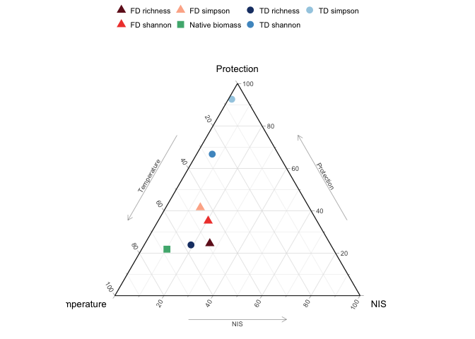

```r
div_ternary_ns <- ggtern(rela_diversity_df_ns,
                         aes(x = Temperature, y = Protection, z = NIS)) +
  geom_point(aes(color = response, shape = response), size = 3.2, alpha = 0.95) +
  labs(x = "Temperature", y = "Protection", z = "NIS", color = NULL, shape = NULL) +
  scale_color_manual(values = div_colors) +
  scale_shape_manual(values = c("TD richness" = 16,
                                "TD shannon" = 16,
                                "TD simpson" = 16,
                                "FD richness" = 17,
                                "FD shannon" = 17,
                                "FD simpson" = 17,
                                "Native biomass" = 15)) +
  theme_bw(base_size = 8) +
  theme_showarrows() +
  theme(legend.position = "top",
        legend.text = element_text(size = 8),
        legend.key.size = unit(0.4, "cm"),
        tern.axis.title.T = element_text(size = 10),
        tern.axis.title.L = element_text(size = 10),
        tern.axis.title.R = element_text(size = 10),
        tern.axis.text.T = element_text(size = 7),
        tern.axis.text.L = element_text(size = 7),
        tern.axis.text.R = element_text(size = 7),
        tern.axis.arrow.text.T = element_text(size = 7),
        tern.axis.arrow.text.L = element_text(size = 7),
        tern.axis.arrow.text.R = element_text(size = 7),
        tern.panel.grid.major = element_line(color = "grey88", linewidth = 0.25),
        plot.margin = margin(1, 1, 1, 1))

div_ternary_ns
```

```r
# ggsave(here("6_SAR",
#             "Ternary_relative_importance_diversity_no_spatial.pdf"),
#             plot = div_ternary_ns,
#             width = 8.5, height = 8.5, units = "cm")
```

biomass plots

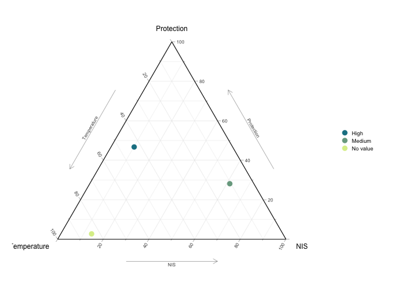

```r
rela_biomass_df_ns <- bind_rows(
  biomass_high_rela_ns$rela,
  biomass_medium_rela_ns$rela,
  biomass_none_rela_ns$rela
) %>%
  mutate(response_short = recode(response,
                                 "High commercial value" = "High",
                                 "Medium commercial value" = "Medium",
                                 "No commercial value" = "No value"))

bio_ternary_ns <- ggtern(
  rela_biomass_df_ns,
  aes(x = Temperature,
      y = Protection,
      z = NIS)) + geom_point(
    aes(color = response_short,
        size = response_short),
    shape = 16,
    alpha = 0.95) +
  labs(x = "Temperature",y = "Protection",z = "NIS",color = NULL, size = NULL) +
  scale_color_manual(values = bio_colors) +
  scale_size_manual(values = c(
    "High" = 3.0,
    "Medium" = 3.0,
    "No value" = 3.0)) +
  theme_bw(base_size = 8) +
  theme_showarrows() +
  theme(
    legend.position = "right",
    legend.text = element_text(size = 7),
    legend.key.size = unit(0.35, "cm"),
    tern.axis.title.T = element_text(size = 9),
    tern.axis.title.L = element_text(size = 9),
    tern.axis.title.R = element_text(size = 9),
    tern.axis.text.T = element_text(size = 6),
    tern.axis.text.L = element_text(size = 6),
    tern.axis.text.R = element_text(size = 6),
    tern.axis.arrow.text.T = element_text(size = 6),
    tern.axis.arrow.text.L = element_text(size = 6),
    tern.axis.arrow.text.R = element_text(size = 6),
    tern.panel.grid.major = element_line(color = "grey90", linewidth = 0.2),
    plot.margin = margin(3, 10, 3, 3))

bio_ternary_ns
```

```r
# ggsave(here("6_SAR","Ternary_relative_importance_biomass_no_spatial.pdf"),
#   plot = bio_ternary_ns,
#   width = 8.5,
#   height = 8.5,
#   units = "cm")
```